# scRNAseq data analysis CRISPR Screening BM: Filtering low quality cells and genes - QC and doublet removal

Researcher: Luís Galan

Author: Eric Canton - María Maqueda

13th August 2024

# Scope

This document aims to filter out poor quality cells and genes. This is an standard first QC step for the scRNAseq data pre-processing analysis. Commonly used QC metrics include the exploration of number of unique genes detected in each cell or the percentage of reads that map to the mitochondrial genome.

# Primary data

- CD45+ cells at 4.5 months (**CD45_4_5**)
- CD45+ cells transplanted from KDR+ progenitors at 4.5 months (**CD45_BFP_4_5**) activated from 7* specific genes identified by CRISPRa in an earlier project phase.

*Genes related to HSC development fate.

# Methods

Following criteria is applied:

- Cells with mitochondrial content higher than **12%** are discarded.
- Cells with less than 500 counts are discarded.
- Cells with more than 10k genes or less than 300 genes are discarded.

Ribosomal genes are removed from the dataset. Additionally, those genes expressed in 5 or less cells (among all samples) are also discarded.

QC is performed by means of Seurat R package (Hao et al. 2023) (v5.0.0).

REMARKS: (a) Applied criteria is quite permissive since, in general, it is expected to conduct a second round of QC (b) Cells classified as doublets/multiplets per sample, identified in a previous analysis, will be also inspected.

# Results

All scRNAseq data samples were merged into a Seurat object

```
## An object of class Seurat
## 32285 features across 14096 samples within 1 assay
## Active assay: RNA (32285 features, 0 variable features)
##  2 layers present: counts.CD45_4_5.1, counts.CD45_BFP_4_5.2
```

## Doublets removal

Number of cells per sample: initially and after doublets removal

| Sample.ID | Initial.Cells | Cells.woDBL |
| --- | --- | --- |
| CD45_4_5 | 8461 | 7641 |
| CD45_BFP_4_5 | 5635 | 5294 |

## QC metrics

### Exploration

Prior to apply any QC filtering, first a general exploration is conducted to assess the overall cells quality. This includes, per barcode (cell):

- Number of genes
- Number of counts
- Mitochondrial content
- Ribosomal content

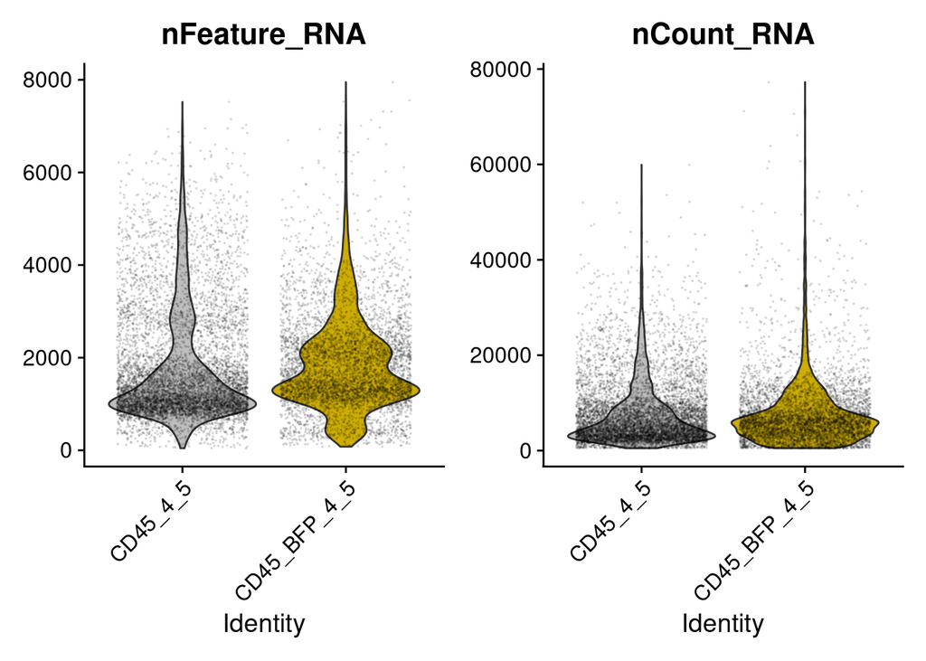

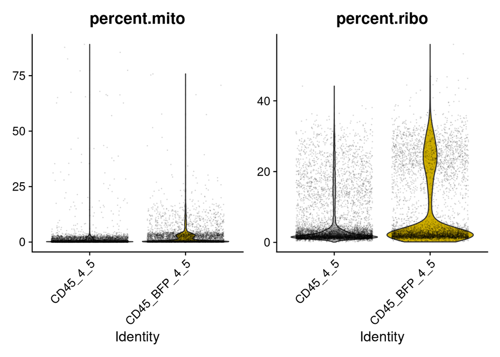

Alternatively, a joint plot between metrics is also of interest to check relationships among variables.

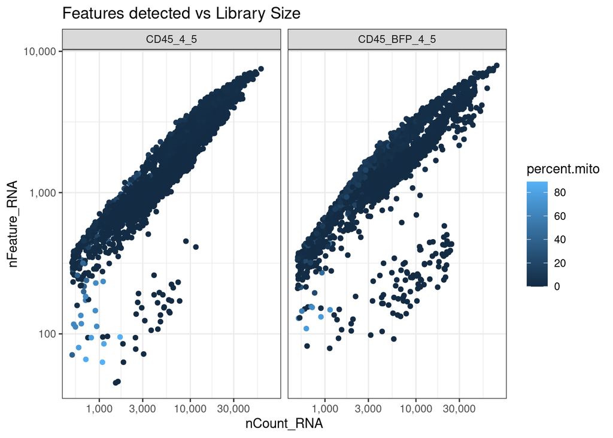

All samples behave roughly equally independently of their condition.

### Subset low quality cells

Cells are subset based on above mentioned QC criteria. The final number of cells is shown in the following table.

Number of cells per sample: initially, after doublets removal and after final QC criteria

| Sample.ID | Initial.Cells | Cells.woDBL | Cells.FINAL |
| --- | --- | --- | --- |
| CD45_4_5 | 8461 | 7641 | 7510 |
| CD45_BFP_4_5 | 5635 | 5294 | 5020 |

After filtering, QC plots are again visualized:

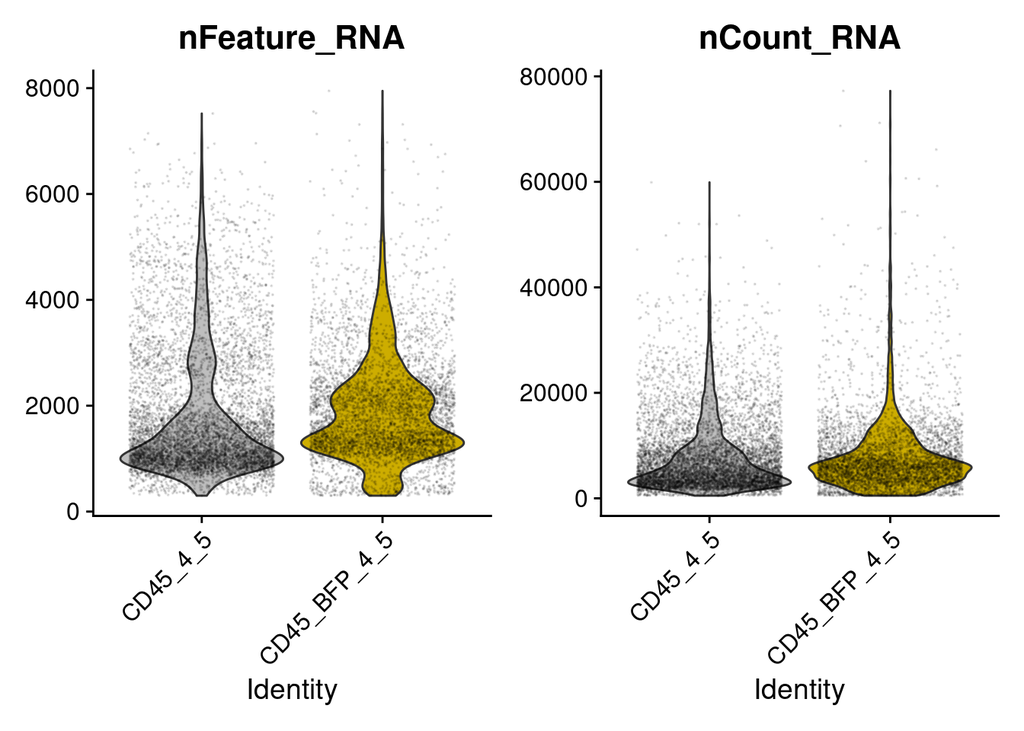

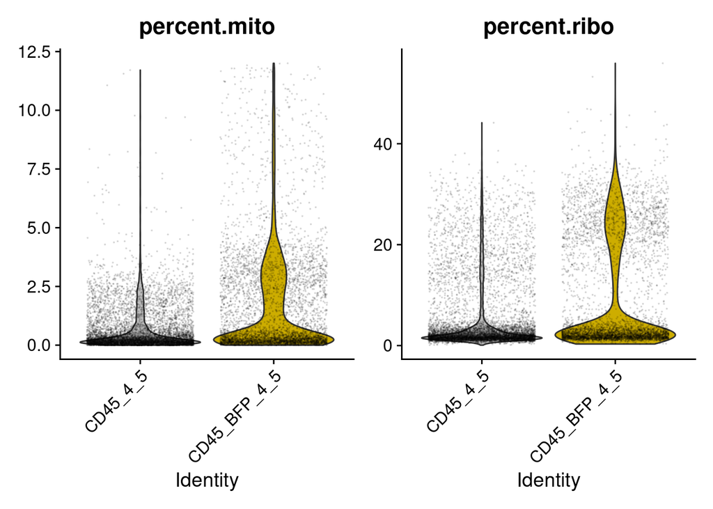

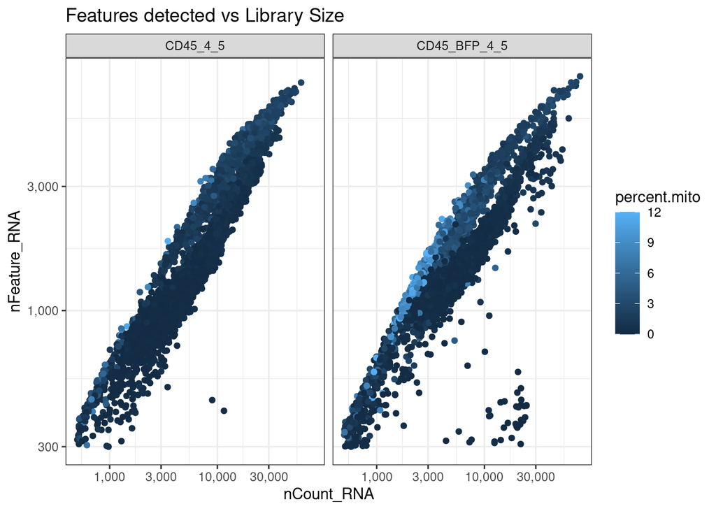

### Discard non-expressed and ribosomal genes

Finally, those genes that are expressed in less than 5 (considering all samples together) will be discarded. The number of cells expressing a particular gene, per sample, is computed:

Example of number of cells expressing a particular gene (in rows) per sample (columns)

|  | counts.CD45_4_5 | counts.CD45_BFP_4_5 |
| --- | --- | --- |
| Xkr4 | 46 | 25 |
| Gm1992 | 0 | 1 |
| Gm19938 | 0 | 0 |
| Gm37381 | 0 | 0 |
| Rp1 | 11 | 3 |
| Sox17 | 0 | 0 |
| Gm37587 | 0 | 0 |
| Gm37323 | 0 | 0 |
| Mrpl15 | 1232 | 931 |
| Lypla1 | 1374 | 916 |

As a reminder, a total of 32285 genes were initially included in the expression matrix (for all samples). Out of those, 17837 are kept for downstream analysis, after discarding the non-expressed ones (or just residual).

Finally, **ribosomal genes are removed from this dataset**. The number of present ribosomal genes are 96 genes.

The **final dataset includes a total of 17741 features (genes) over 12530 cells distributed in two conditions. Doublet cells have been removed.**

# References

Hao, Yuhan, Tim Stuart, Madeline H Kowalski, Saket Choudhary, Paul Hoffman, Austin Hartman, Avi Srivastava, et al. 2023. “Dictionary Learning for Integrative, Multimodal and Scalable Single-Cell Analysis.” *Nature Biotechnology*. https://doi.org/10.1038/s41587-023-01767-y.